# **Project #2: Polio in Modern Times**

Hello, all readers! My name is Daniel Miller. I am a freshman at Pennsylvania State University, studying applied data science. This is my first exploratory data analysis project, and I have chosen to analyze something that has always fascinated me. Going into this project, I initially had a few different subjects on my mind. First, I had it in my head that I would explore some data on weather and climate, possibly to see if the conclusions made regarding climate change were as serious as the news claimed. However, with further thought, I have decided that it would be more interesting to delve into an infectious disease. In particular, some of the infectious diseases that once plagued the world amassed hundreds of thousands of cases as the developing world took shape in the 19th and 20th centuries. Unfortunately, the data on viruses such as smallpox and the Spanish flu was not easy to come across, and making any conclusions would all be a retrospective analysis.

Therefore, I decided to choose a disease that was once a very infectious disease but has not been eradicated, like smallpox. When speaking with my parents, who had grown up during the 1980's, they mentioned that a large-scale virus amongst families in the United States of America was the spread of polio.

The polio virus, scientifically referred to as poliomyelitis, was feared by parents across the globe as it occurred primarily in children ages 5 or under. It would initially appear as a cold, with fever, fatigue, and headache as the initial symptoms. However, it could lead to permanent paralysis. In particular, paralysis in the lower extremities and possibly even death if the paralysis takes form in the neck. Famously, President Franklin Delanor Roosevelt suffered greatly from the disease beginning at age 39, although it is quite uncommon for the virus to affect someone of that age.

As this is such an old virus, I think that it is important to study how polio terrorized the world. Aside from the origin of the virus, it is important in the field of data science to learn how it continues to affect people in more modern times, to learn from the past, and to prepare for what is to come of Polio and the newer virus' to improve future prevention measures. In the realm of biological warfare, a virus like polio could cripple the human race, and understanding how to fight disease is just as important as creating the cure.

# **Data Gathering**

In looking for an open source database, I first looked through all of the government database websites and then turned my attention to some user-based websites, with no luck. However, when I searched through the CDC's databases, I found two that seemed particularly interesting. In the first, the number of reported polio cases in the majority of countries across the world from 1980–2020. Although I tried to find data on the cases before 1980, I had no luck in finding such a dataset. The second dataset I found illustrates the percentage of the U.S. population that has received the vaccine between 1962 and 2009. In my search, this was the largest range of years that I could find with a reliable dataset. I obtained the data for the first dataset from the Global Change Data Lab through their online publication at the link: https://ourworldindata.org/polio#all-charts. If you scroll to the bottom of the page, it can be downloaded in the second chart once selected.

First, I will import the Pandas and Matplotlib libraries for the purposes of this project. Pandas is a software library that is used for the purposes of data analysis and formatting, offering data structures and ways to manipulate the data set to create tables. If you would like to look more into the Pandas library, you can view the link: https://pandas.pydata.org/. Next, I will import the Matplotlib library, which will only be used to plot the data in bar graphs and even scatter plots. Then I will use the pd.read_csv() function from the Pandas library to import the first dataset, as seen below.

```python
import pandas as pd
import matplotlib.pyplot as plt
df = pd.read_csv("/content/number-of-estimated-paralytic-polio-cases-by-world-region-pivoted.csv")
df
```

|  | Country | 1980 | 1981 | 1982 | 1983 | 1984 | 1985 | 1986 | 1987 | 1988 | ... | 2012 | 2013 | 2014 | 2015 | 2016 | 2017 | 2018 | 2019 | 2020 | Total Result |
| --- | --- | --- | --- | --- | --- | --- | --- | --- | --- | --- | --- | --- | --- | --- | --- | --- | --- | --- | --- | --- | --- |
| 0 | Afghanistan | 6160.0 | 5859.0 | 9730.0 | 13937.0 | 3864.0 | 13867.0 | 12901.0 | 4396.0 | 2149.0 | ... | 51.0 | 19.0 | 31.0 | 22.0 | 14.0 | 16.0 | 23.0 | 32.0 | 404.0 | 74904 |
| 1 | Albania | 7.0 | 7.0 | 0.0 | 0.0 | 0.0 | 7.0 | 0.0 | 0.0 | 0.0 | ... | 0.0 | 0.0 | 0.0 | 0.0 | 0.0 | 0.0 | 0.0 | 0.0 | 0.0 | 188 |
| 2 | Algeria | 812.0 | 798.0 | 497.0 | 924.0 | 756.0 | 462.0 | 203.0 | 245.0 | 63.0 | ... | 0.0 | 0.0 | 0.0 | 0.0 | 0.0 | 0.0 | 0.0 | 0.0 | 0.0 | 4991 |
| 3 | Angola | 224.0 | 84.0 | 42.0 | 0.0 | 21.0 | 98.0 | 259.0 | 105.0 | 0.0 | ... | 0.0 | 0.0 | 0.0 | 0.0 | 0.0 | 0.0 | 0.0 | 153.0 | 6.0 | 5075 |
| 4 | Argentina | 224.0 | 14.0 | 84.0 | 182.0 | 7.0 | 14.0 | 0.0 | 0.0 | 0.0 | ... | 0.0 | 0.0 | 0.0 | 0.0 | 0.0 | 0.0 | 0.0 | 0.0 | 0.0 | 525 |
| ... | ... | ... | ... | ... | ... | ... | ... | ... | ... | ... | ... | ... | ... | ... | ... | ... | ... | ... | ... | ... | ... |
| 145 | Venezuela | 77.0 | 476.0 | 210.0 | 63.0 | 63.0 | 56.0 | 189.0 | 322.0 | 119.0 | ... | 0.0 | 0.0 | 0.0 | 0.0 | 0.0 | 0.0 | 0.0 | 0.0 | 0.0 | 1687 |
| 146 | Vietnam | 12187.0 | 4508.0 | 6279.0 | 7763.0 | 8106.0 | 11200.0 | 6566.0 | 10143.0 | 5873.0 | ... | 0.0 | 0.0 | 0.0 | 0.0 | 0.0 | 0.0 | 0.0 | 0.0 | 0.0 | 93831 |
| 147 | Yemen | 5054.0 | 3787.0 | 1645.0 | 4431.0 | 5369.0 | 2352.0 | 4207.0 | 1253.0 | 798.0 | ... | 2.0 | 1.0 | 0.0 | 0.0 | 0.0 | 0.0 | 0.0 | 1.0 | 34.0 | 37298 |
| 148 | Zambia | 1932.0 | 3003.0 | 1701.0 | 1274.0 | 1239.0 | 896.0 | 938.0 | 483.0 | 595.0 | ... | 0.0 | 0.0 | 0.0 | 0.0 | 0.0 | 0.0 | 0.0 | 2.0 | 0.0 | 15765 |
| 149 | Zimbabwe | 224.0 | 196.0 | 63.0 | 21.0 | 28.0 | 483.0 | 644.0 | 35.0 | 28.0 | ... | 0.0 | 0.0 | 0.0 | 0.0 | 0.0 | 0.0 | 0.0 | 0.0 | 0.0 | 1796 |

150 rows × 43 columns

Please note that if you download the data from the CDC website, it will not look exactly the same, as I have reformatted the data to make it easier to play with.

Also note that the cases in the data frame include only the cases of polio that resulted in paralysis as a symptom, so it is likely that many more cases have resulted in more mild or even asymptomatic cases. However, as I have no access to that data, I will use only what is included in the dataset.

Before I begin the breakdown of the data, I will clean the data by testing for and removing null values, then making sure there are no duplicate values.

The code df.columns reveals the individual columns in the data frame I have created above.

```python
df.columns
```

```
Index(['Country', '1980', '1981', '1982', '1983', '1984', '1985', '1986',
       '1987', '1988', '1989', '1990', '1991', '1992', '1993', '1994', '1995',
       '1996', '1997', '1998', '1999', '2000', '2001', '2002', '2003', '2004',
       '2005', '2006', '2007', '2008', '2009', '2010', '2011', '2012', '2013',
       '2014', '2015', '2016', '2017', '2018', '2019', '2020', 'Total Result'],
      dtype='object')
```

The code df.isnull().sum() indicates the number of null/empty values in each column of the data frame.

```python
df.isnull().sum()
```

```
Country          0
1980            20
1981            20
1982            20
1983            18
1984            15
1985            18
1986            18
1987            19
1988            16
1989            16
1990            20
1991             9
1992             8
1993             9
```

[output cut: 29 more lines]

I am going to use the dropna() function with passing throw how='all' and axis = 0, where the axis indicates rows of the dataframe, and how indicates that all of the values must be 0 for it to remove the row. This will remove all of the empty rows in the data frame. Then the code df.duplicated().sum() will return the number of duplicated rows in the code, which indicates that there are no duplicated rows.

```python
df.dropna(how = 'all', subset = ['1980','1981','1982','1983','1984','1985','1986','1987','1988','1989','1990','1991','1992','1993','1994','1995','1996','1997','1998','1999','2000','2001','2002','2003','2004','2005','2006','2007','2007','2008','2009','2010','2011','2012','2013','2014','2015','2016','2017','2018','2019','2020'],inplace=True)
"There are a total of " + str(df.duplicated().sum()) + " duplicated rows."
```

```
'There are a total of 0 duplicated rows.'
```

To begin the basic data analysis, we will look at the average cases in each column/year using the df.mean() function.

```python
df.mean()
```

```
1980             2854.600000
1981             3557.776923
1982             2797.846154
1983             2133.090909
1984             1826.014815
1985             2046.174242
1986             1743.901515
1987             2121.641221
1988             1805.305970
1989             1161.902985
1990             1013.607692
1991              593.680851
1992              713.697183
1993              531.851064
1994              426.952055
```

[output cut: 28 more lines]

Now we will look at the std deviation of each column of the dataset using the df.std() function.

```python
df.std()
```

```
1980             12865.954989
1981             24154.329252
1982             16913.805174
1983             15171.896651
1984             13954.831521
1985             13882.315515
1986             12357.327490
1987             17310.221651
1988             14442.957534
1989              8485.292415
1990              6579.636045
1991              3599.052898
1992              5581.811759
1993              2813.062713
1994              2817.768697
```

[output cut: 28 more lines]

Next, we will find the minimum and maximum of the dataset using df[].min() and df[].max(), passing through all of the columns except for the country name, as they would be alphabetically ranked.

```python
df[['1980','1981','1982','1983','1984','1985','1986','1987','1988','1989','1990','1991','1992','1993','1994','1995','1996','1997','1998','1999','2000','2001','2002','2003','2004','2005','2006','2007','2007','2008','2009','2010','2011','2012','2013','2014','2015','2016','2017','2018','2019','2020','Total Result']].min()
```

```
1980            0.0
1981            0.0
1982            0.0
1983            0.0
1984            0.0
1985            0.0
1986            0.0
1987            0.0
1988            0.0
1989            0.0
1990            0.0
1991            0.0
1992            0.0
1993            0.0
1994            0.0
```

[output cut: 29 more lines]

```python
df[['1980','1981','1982','1983','1984','1985','1986','1987','1988','1989','1990','1991','1992','1993','1994','1995','1996','1997','1998','1999','2000','2001','2002','2003','2004','2005','2006','2007','2007','2008','2009','2010','2011','2012','2013','2014','2015','2016','2017','2018','2019','2020','Total Result']].max()
```

```
1980             132825.0
1981             266630.0
1982             184079.0
1983             172641.0
1984             161749.0
1985             157990.0
1986             141050.0
1987             197848.0
1988             166600.0
1989              97405.0
1990              72856.0
1991              41272.0
1992              65765.0
1993              29659.0
1994              33537.0
```

[output cut: 29 more lines]

Now that we have some basic data on the dataset, it is time to acknowledge what I intend to answer throughout the course of this project. For each question, I will address how I intend to use the dataset to come up with some data and derive a conclusion.

# **Question 1, How widespread was paralytic poliomyelitus?**

To begin my real analysis, I would like to find out how many cases and how many countries have suffered since 1980. Answering this question will give me a better understanding of the cause of the spread of paralytic poliomyelitis. In order to find the answer, I will employ functions from the Pandas library.

First, I will use the df[].sum() function to calculate the sum across each column of the dataframe, by passing through each column.

```python
sum = df[['1980','1981','1982','1983','1984','1985','1986','1987','1988','1989','1990','1991','1992','1993','1994','1995','1996','1997','1998','1999','2000','2001','2002','2003','2004','2005','2006','2007','2007','2008','2009','2010','2011','2012','2013','2014','2015','2016','2017','2018','2019','2020','Total Result']].sum()
sum
```

```
1980             371098.0
1981             462511.0
1982             363720.0
1983             281568.0
1984             246512.0
1985             270095.0
1986             230195.0
1987             277935.0
1988             241911.0
1989             155695.0
1990             131769.0
1991              83709.0
1992             101345.0
1993              74991.0
1994              62335.0
```

[output cut: 29 more lines]

This shows that there have been a total of 3.46 million cases since the 1980s, since the sum() function extracts the sum of each column specified, the years individually, and the total for each country over the years in Total Result at the bottom. This shows that the disease has been a threat in various regions of the world since the 1980s. However, to truly answer the question, we need to see how many countries have reported cases in the dataset.

The not_0 variable contains all of the rows that have reported a case of paralytic polio since 1980. I will use the not_0.shape function to show how many countries have reported cases of polio in the past 40 years.

```python
not_0 = df[df['Total Result'] > 0][['Country','Total Result']]
not_0.shape
```

```
(150, 2)
```

# **Answer to Question 1:**

The code above shows that 150 countries have reported cases and over 3.46 million cases have been reported in the last 40 years. This means that polio has presented itself as a widespread disease across the last 40 years.

# **Question 2, Which country has suffered the most from poliomyelitus?**

Next, I would like to get a more in-depth focus on the dataset, looking for the most affected countries. To answer my question, I will generate a query to show the countries that have the highest number of total cases in the column 'Total Result'. I will use df.sort_values(), passing through the "Total Result" column in a descending fashion to a new variable titled top_10. I will then output the top 10 data frames with only the name of the country and the total number of cases.

```python
top_10 = df.sort_values('Total Result',ascending = False)[0:10].copy()
top_10[['Country','Total Result']]
```

|  | Country | Total Result |
| --- | --- | --- |
| 61 | India | 1964243 |
| 29 | China | 265030 |
| 103 | Pakistan | 172339 |
| 99 | Nigeria | 95181 |
| 146 | Vietnam | 93831 |
| 40 | Egypt | 86013 |
| 0 | Afghanistan | 74904 |
| 72 | Kenya | 47299 |
| 22 | Cambodia | 42673 |
| 126 | Sudan | 38458 |

As shown in the generated table above, only 3 countries have experienced over 100,000 cases. However, it is obvious that India has experienced the most cases, although this could be due to a multitude of reasons. For instance, they could be more at risk due to unsanitary drinking water and a much higher population than all of the other countries that have published their case counts.

# **Answer to Question 2:**

India is the only country to experience over 300,000 cases. In total, India has experienced over 1.7 million more cases than China, despite nearly identical population sizes. Therefore, India has been the most affected by paralytic poliomyelitis over the last 40 years.

However, it is important to note that countries that are more isolated from world organizations like NATO and the EU make it more difficult to gather accurate data, like North Vietnam or even China, which have been known to report cases to world organizations.

# **Question 3, What trends emerge when plotting the data?**

Now I will employ Matplotlib and Pandas to generate a plot of the data. By plotting the data, I would like to see if there is anything interesting that the change in format shows within the dataset.

In the code below, I first made variables sum2 and countries for the y and x axis' of the graph, respectively, and then I used matplotlib figure and axis to set the number of rows and columns, along with the size of the figure. Then I set the bar graph to have the new variables as their axis', labeling them using plt.xlabel and plt.ylabel. Then I used ax.grid to create a grid pattern on the graph and plt.show() to generate the graph.

```python
sum2 = df['Total Result'] #y-axis
countries = list(df['Country']) #x-axis
fig,ax = plt.subplots(nrows=1,ncols=1,figsize=(120,40))

ax.bar(countries,sum2,align='edge')

plt.xlabel('countries',fontsize=60)
plt.ylabel('Sum of Cases',fontsize=60)
plt.xticks(rotation='vertical',fontsize=20)
plt.title("Total Number of Paralytic Poliomyelitis Cases Each Year (1980-2020)", fontsize = 80)

ax.grid()
plt.show()
```

[figure not shown]

Below, I used the Pandas library to generate the same graph, but without the ability to name the graph and the axis' using df.plot(). I set the x axis equal to the country name column and the y axis equal to the total result column, as done in the previous graph.

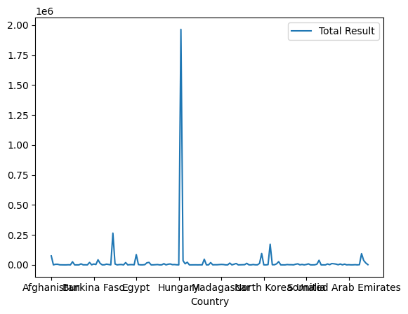

```python
df.plot(x='Country',y='Total Result')
```

# **Answer to Question 3:**

It is obvious from looking at the graphs that there were a select few countries that suffered far more than the rest, and this is reinforced by the tables generated with the top 10 countries with the most cases, but now I will shift the focus to different time periods.

# **Question 4, Where was Polio the most dominant in the early 1980s?**

Since the data collection for paralytic poliomyelitis began in 1980 in the dataset, it is important to clarify where the disease was most dominant when cases were initially being tallied. It can also give us an idea of how the progression of the disease has gone since the 1980s.

To answer this, I will create a new column in the data frame to account for all of the cases in the first 5 years of data spanning from 1980-1984.

```python
df['1980-1984'] = df[['1980','1981','1982','1983','1984']].sum(axis=1)
df[['Country','1980-1984']]
```

|  | Country | 1980-1984 |
| --- | --- | --- |
| 0 | Afghanistan | 39550.0 |
| 1 | Albania | 14.0 |
| 2 | Algeria | 3787.0 |
| 3 | Angola | 371.0 |
| 4 | Argentina | 511.0 |
| ... | ... | ... |
| 145 | Venezuela | 889.0 |
| 146 | Vietnam | 38843.0 |
| 147 | Yemen | 20286.0 |
| 148 | Zambia | 9149.0 |
| 149 | Zimbabwe | 532.0 |

150 rows × 2 columns

Next I will sort the newly generate column and output the top 10 countries using the df.sort_values() function in the same manner as I did when answering question 2.

```python
oldtop10 = df.sort_values('1980-1984',ascending = False)[0:10].copy()
oldtop10[['Country','1980-1984']]
```

|  | Country | 1980-1984 |
| --- | --- | --- |
| 61 | India | 917924.0 |
| 29 | China | 208110.0 |
| 103 | Pakistan | 86212.0 |
| 40 | Egypt | 52577.0 |
| 0 | Afghanistan | 39550.0 |
| 146 | Vietnam | 38843.0 |
| 126 | Sudan | 31423.0 |
| 22 | Cambodia | 21546.0 |
| 147 | Yemen | 20286.0 |
| 99 | Nigeria | 17941.0 |

# **Answer to Question 4:**

Upon one glance at the table generated above, countries in the Middle East and across Asia seem to have reported more cases than any in the western world, although India was subjected to more cases than any of the other countries, as we have seen earlier.

# **Question 5, Where does the disease still exist in the world?**

Now that we have looked at the beginning of the data set, concluding that countries in the Middle East and Asia were at a higher risk of obtaining polio, we can look at the end of the data set. Specifically, looking to the last 5 years, from 2016–2020, when the COVID-19 pandemic began, To do this, I will generate a table to show the countries that have reported the most cases in the last 5 years.

First I have to make a new column in the table that takes the sum across the last 5 years for all of the countries in the dataset.

I will sum the values from the past 5 years into a new column in the dataframe using the df.sum(axis=1) function since axis = 1 means to sum the columns together.

```python
df['2016-2020'] = df[['2016','2017','2018','2019','2020']].sum(axis=1)
df[['Country','2016-2020']]
```

|  | Country | 2016-2020 |
| --- | --- | --- |
| 0 | Afghanistan | 489.0 |
| 1 | Albania | 0.0 |
| 2 | Algeria | 0.0 |
| 3 | Angola | 159.0 |
| 4 | Argentina | 0.0 |
| ... | ... | ... |
| 145 | Venezuela | 0.0 |
| 146 | Vietnam | 0.0 |
| 147 | Yemen | 35.0 |
| 148 | Zambia | 2.0 |
| 149 | Zimbabwe | 0.0 |

150 rows × 2 columns

Next, I will take the top 10 from the new column to find out where the polio virus is still prevalent using the .sort_values() function as done previously.

```python
newtop10 = df.sort_values('2016-2020',ascending = False)[0:10].copy()
newtop10[['Country','2016-2020']]
```

|  | Country | 2016-2020 |
| --- | --- | --- |
| 0 | Afghanistan | 489.0 |
| 103 | Pakistan | 476.0 |
| 35 | Democratic Republic of Congo | 324.0 |
| 27 | Chad | 214.0 |
| 3 | Angola | 159.0 |
| 20 | Burkina Faso | 131.0 |
| 33 | Cote d'Ivoire | 128.0 |
| 84 | Mali | 104.0 |
| 123 | South Sudan | 100.0 |
| 45 | Ethiopia | 88.0 |

I will use the Pandas libraries df.plot.bar(x,y) function to pass through the country names and the new column of the last 5 years of the dataset to make a bar graph.

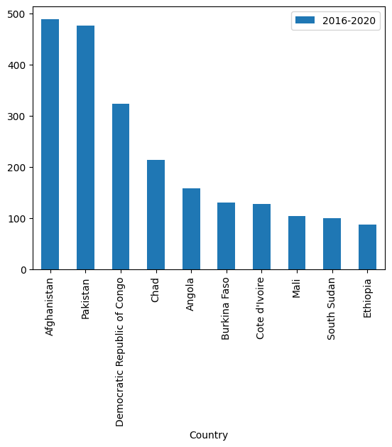

```python
newtop10.plot.bar(x='Country',y='2016-2020')
```

# **Answer to Question 5:**

Performing an analysis on the lists generated, it is interesting to note that all of the countries that continue to have cases of paralytic poliomyelitis are occurring in third-world or developing countries, as all of the developed world has seemingly eradicated the disease. Many people know that polio has had a vaccine created in the United States of America, and it is typical for children to receive multiple shots of the live vaccine to fight against further infection.